# Scholarly API Cookbook

Powered by [Jupyter Book](https://jupyterbook.org)

- [repository](https://github.com/ualibweb/UALIB_ScholarlyAPI_Cookbook)
- [open issue](https://github.com/ualibweb/UALIB_ScholarlyAPI_Cookbook/issues/new?title=Issue%20on%20page%20%2Fcontent/scripts/mathematica/mathematica_worldbank.html&body=Your%20issue%20content%20here.)
- .ipynb

Contents

# …in Mathematica

## World Bank Data API in Mathematica

by Vishank Patel

See the [World Bank API documentation](https://datahelpdesk.worldbank.org/knowledgebase/articles/889392-about-the-indicators-api-documentation)

These recipe examples were tested on February 8, 2022

### 1. Get list of country iso2Codes and names

Define root WorldBank API

```
urlRoot = "https://api.worldbank.org/v2/";
```

For obtaining data from the World Bank API, it is helpful to first obtain a list of country codes and names. We will build the API URL using the URLBuild command:

```
countryURL = URLBuild[{urlRoot, "country"}, {"format" -> "json", "per_page" -> 500}]
```

```
https://api.worldbank.org/v2/country?format=json&per_page=500
```

And then URLExecute to execute the request:

```
rawCountryData = URLExecute[countryURL] // Short
```

```
countryData = rawCountryData[[1, 2]];
countryData // Dataset
```

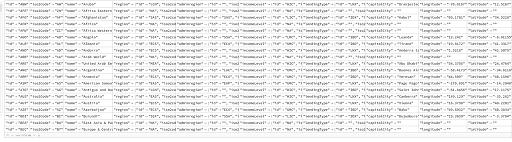

[output not shown]

Extract country names:

```
countryName = "name" /. countryData;
countryName // Shallow
```

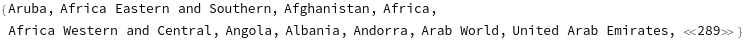

```
countryIso2CodeName = Transpose[{countryIso2Code, countryName}];
countryIso2CodeName // Shallow
```

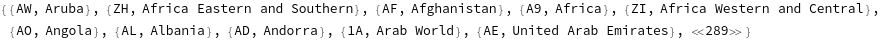

So now we know the country iso2codes, which we can use to pull specific indicator data for countries.

### 2. Compile a Custom Indicator Dataset

There are many availabe indicators: https://data.worldbank.org/indicator

We wll select three indicators for this example:

1. Scientific and Technical Journal Article Data = [IP.JRN.ARTC.SC](https://data.worldbank.org/indicator/IP.JRN.ARTC.SC?view=chart)
2. Patent Applications, residents = [IP.PAT.RESD](https://data.worldbank.org/indicator/IP.PAT.RESD?view=chart)
3. GDP per capita (current US$) Code = [NY.GDP.PCAP.CD](https://data.worldbank.org/indicator/NY.GDP.PCAP.CD?view=chart)

Note that these three selected indictaors have a [CC-BY 4.0 license](https://datacatalog.worldbank.org/public-licenses#cc-by). We will compile this indicator data for the United States (US) and United Kingdom (GB)

```
indicators = {"IP.JRN.ARTC.SC", "IP.PAT.RESD", "NY.GDP.PCAP.CD"}
```

```
{IP.JRN.ARTC.SC, IP.PAT.RESD, NY.GDP.PCAP.CD}
```

Generate the web API URLs we need for U.S.:

```
USApiURL = {};
For[
 i = 1, i <= Length[indicators], i++,
 AppendTo[USApiURL,
  URLBuild[{urlRoot, "country", "US", "indicator",
    indicators[[i]]}, {"format" -> "json", "per_page" -> 500}]]
 ]
USApiURL
```

```
{https://api.worldbank.org/v2/country/US/indicator/IP.JRN.ARTC.SC?format=json&per_page=5\

>    00, https://api.worldbank.org/v2/country/US/indicator/IP.PAT.RESD?format=json&per_p\

>    age=500, https://api.worldbank.org/v2/country/US/indicator/NY.GDP.PCAP.CD?format=js\

>    on&per_page=500}
```

Retrieving Data

```
USIndicatorData = {};
For[
 j = 1, j <= Length[USApiURL], j++,
 AppendTo[USIndicatorData, URLExecute[USApiURL[[j]]]];
 Pause[1]
 ]
```

```
USJournalData = {"date", "value"} /. USIndicatorData[[1, 2]]
```

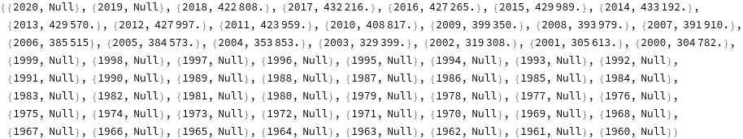

```
USPatentData = {"date", "value"} /. USIndicatorData[[2, 2]]
```

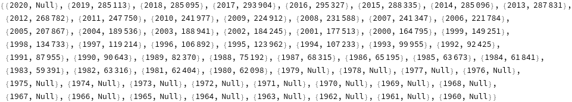

```
USGdpData = {"date", "value"} /. USIndicatorData[[3, 2]]
```

```
{{2020, 63413.5}, {2019, 65279.5}, {2018, 63064.4}, {2017, 60109.7}, {2016, 58021.4},

>   {2015, 56863.4}, {2014, 55050.}, {2013, 53106.5}, {2012, 51602.9}, {2011, 49882.6},

>   {2010, 48466.7}, {2009, 47100.}, {2008, 48382.6}, {2007, 47976.}, {2006, 46298.7},

>   {2005, 44114.7}, {2004, 41712.8}, {2003, 39496.5}, {2002, 38023.2}, {2001, 37133.2},

>   {2000, 36334.9}, {1999, 34513.6}, {1998, 32853.7}, {1997, 31459.1}, {1996, 29967.7},

>   {1995, 28690.9}, {1994, 27694.9}, {1993, 26387.3}, {1992, 25419.}, {1991, 24342.3},

>   {1990, 23888.6}, {1989, 22857.2}, {1988, 21417.}, {1987, 20038.9}, {1986, 19071.2},

>   {1985, 18236.8}, {1984, 17121.2}, {1983, 15543.9}, {1982, 14433.8}, {1981, 13976.1},

>   {1980, 12574.8}, {1979, 11674.2}, {1978, 10564.9}, {1977, 9452.58}, {1976, 8592.25},

>   {1975, 7801.46}, {1974, 7225.69}, {1973, 6726.36}, {1972, 6094.02}, {1971, 5609.38},

>   {1970, 5234.3}, {1969, 5032.14}, {1968, 4695.92}, {1967, 4336.43}, {1966, 4146.32},

>   {1965, 3827.53}, {1964, 3573.94}, {1963, 3374.52}, {1962, 3243.84}, {1961, 3066.56},

>   {1960, 3007.12}}
```

```
USData = Transpose[{USJournalData, USPatentData, USGdpData}];
USData // Dataset
```

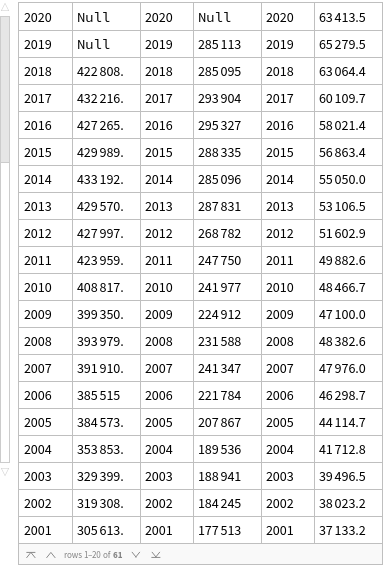

For the United Kingdom:

```
UKApiURL = {};
For[
 i = 1, i <= Length[indicators], i++,
 AppendTo[UKApiURL,
  URLBuild[{urlRoot, "country", "GB", "indicator",
    indicators[[i]]}, {"format" -> "json", "per_page" -> 500}]]
 ]
UKApiURL
```

```
{https://api.worldbank.org/v2/country/GB/indicator/IP.JRN.ARTC.SC?format=json&per_page=5\

>    00, https://api.worldbank.org/v2/country/GB/indicator/IP.PAT.RESD?format=json&per_p\

>    age=500, https://api.worldbank.org/v2/country/GB/indicator/NY.GDP.PCAP.CD?format=js\

>    on&per_page=500}
```

```
UKIndicatorData = {};
For[
 j = 1, j <= Length[UKApiURL], j++,
 AppendTo[UKIndicatorData, URLExecute[UKApiURL[[j]]]];
 Pause[1]
 ]
```

```
UKIndicatorData // Dataset
```

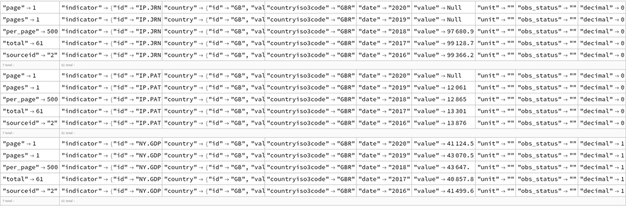

```
UKJournalData = {"date", "value"} /. UKIndicatorData[[1, 2]];
UKPatentData = {"date", "value"} /. UKIndicatorData[[2, 2]];
UKGdpData = {"date", "value"} /. UKIndicatorData[[3, 2]];
UKData = Transpose[{UKJournalData, UKPatentData, UKGdpData}];
UKData // Dataset
```

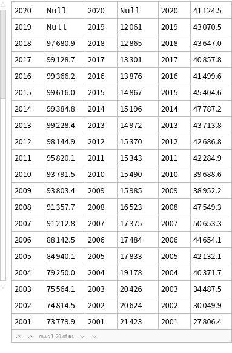

```
USJournalData
```

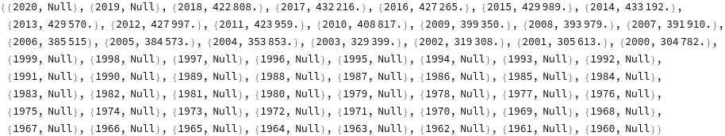

### 3. Plot Indicator data

```
DateListPlot[{USJournalData[[;; 21]], UKJournalData[[;; 21]]},
 PlotMarkers -> Automatic, PlotLegends -> {"US IP", "UK IP"}, PlotTheme -> "Detailed"]
```

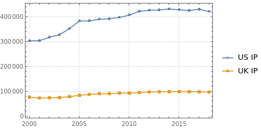

```
DateListPlot[{USGdpData[[;; 21]], UKGdpData[[;; 21]]},
 PlotMarkers -> Automatic, PlotLegends -> {"US GDP", "UK GDP"}, PlotTheme -> "Detailed"]
```

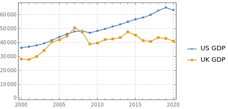

```
DateListPlot[{USPatentData[[;; 41]], UKPatentData[[;; 41]]},
 PlotMarkers -> Automatic, PlotLegends -> {"US Patents", "UK Patents"}, PlotTheme -> "Detailed"]
```

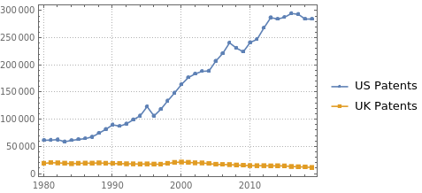